# Aplicação Psicobiologia

Lourdes M.M.Villavicencio

7 de novembro de 2018

## Aplicação

Vamos nos concentrar em um sistema de estudo fictício, para que não tenhamos que nos distrair muito com as especificidades deste exemplo. Imagine que decidimos treinar condores, e então saímos para as montanhas da região andina do Peru e coletamos dados sobre a inteligência do condor( testScore) como um pré-requisito. Amostramos indivíduos em uma variedade de comprimentos corporais, em três locais e em oito montanhas diferentes.

## Carregue o diretorio do trabalho

```r
setwd("~/Minicurso")
library(ggplot2)
```

## Chamar ao Banco de Dados

```r
condor<- read.table("condor.csv" , ",", header=TRUE)
attach(condor)
## Vamos visualizar parte dos dados
head(condor)
```

```
##   Pontuacao ComprimentoCorpo  Montanha Local
## 1 16.147309         165.5485 Huascaran     a
## 2 33.886183         167.5593 Huascaran     a
## 3  6.038333         165.8830 Huascaran     a
## 4 18.838821         167.6855 Huascaran     a
## 5 33.862328         169.9597 Huascaran     a
## 6 47.043246         168.6887 Huascaran     a
```

```r
#View(condor)
#Vamos a visualizar os nomes das variaveis
names(condor)
```

```
## [1] "Pontuacao"        "ComprimentoCorpo" "Montanha"
## [4] "Local"
```

## Queremos saber como o comprimento do corpo dos condores afeta aos resultados dos testes.

Coloque todos os dados em uma análise, uma maneira de analisar esses dados seria ajustar um modelo linear a todos os nossos dados, ignorando os locais e as cadeias montanhosas por enquanto.

## Ajuste o modelo com Pontuação (resposta) e ComprimentoCorpo como o preditor

```r
modelo1 <- lm(Pontuacao ~ ComprimentoCorpo, data = condor)
anova(modelo1)
```

```
## Analysis of Variance Table
##
## Response: Pontuacao
##                   Df Sum Sq Mean Sq F value    Pr(>F)
## ComprimentoCorpo   1  38761   38761  86.247 < 2.2e-16 ***
## Residuals        478 214824     449
## ---
## Signif. codes:  0 '***' 0.001 '**' 0.01 '*' 0.05 '.' 0.1 ' ' 1
```

## Vamos traçar os dados com ggplot2

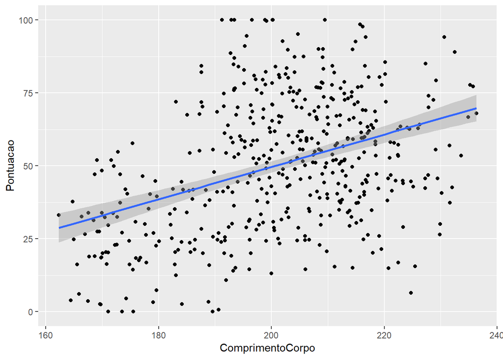

```r
library(ggplot2) ##carregamos o pacote
ggplot(condor, aes(x = ComprimentoCorpo, y = Pontuacao)) +
  geom_point() + geom_smooth(method = "lm")
```

Parece que condores maiores saem melhor no teste de inteligência. Isso parece um pouco estranho: o tamanho não deve realmente afetar os resultados das pontuações dos testes.

# E as suposições são satisfeitas?

Plotemos os resíduos: a linha vermelha deve ser quase plana, como a linha cinza tracejada:

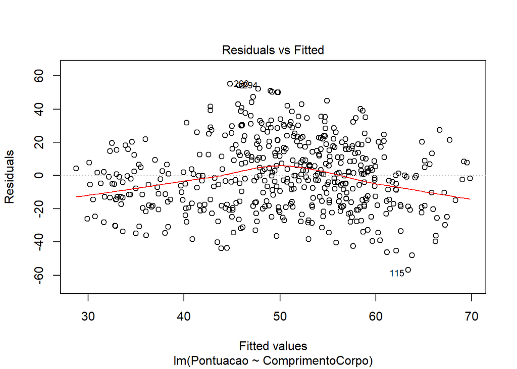

```r
plot(modelo1, which = 1)
```

Mas como este é um exemplo fictício, nós iremos com ele, no entanto para seus próprios dados, tenha cuidado: Dê uma olhada rápida no qqplot também, os pontos devem idealmente cair na linha tracejada diagonal:

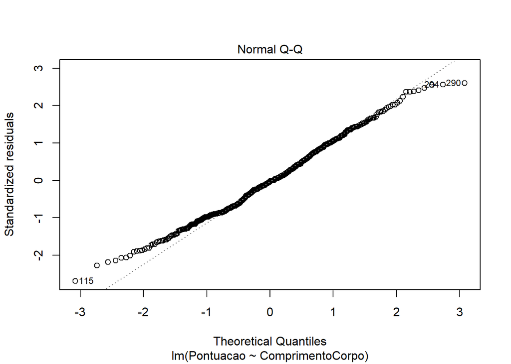

```r
plot(modelo1, which = 2)  ## não parece tão ruim
```

No entanto, o que dizer de independência de observação? Nossos dados são independentes? Coletamos várias amostras de oito cadeias de montanhas. É perfeitamente plausível que os dados de cada cadeia de montanhas sejam mais semelhantes entre si do que os dados de diferentes cadeias montanhosas: eles são correlacionados.

## Dê uma olhada nos dados para ver se é verdade.

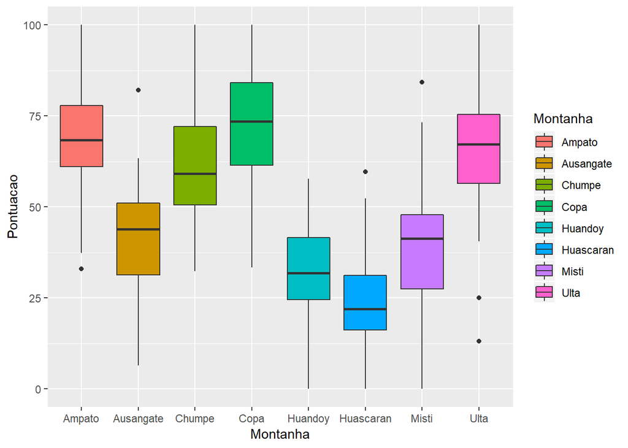

```r
ggplot(condor, aes(x = Montanha, y = Pontuacao, fill = Montanha)) +
  geom_boxplot()  # certamente parece que algo está acontecendo aqui
```

## Poderíamos também plotar os pontos de cor e cor por montanha:

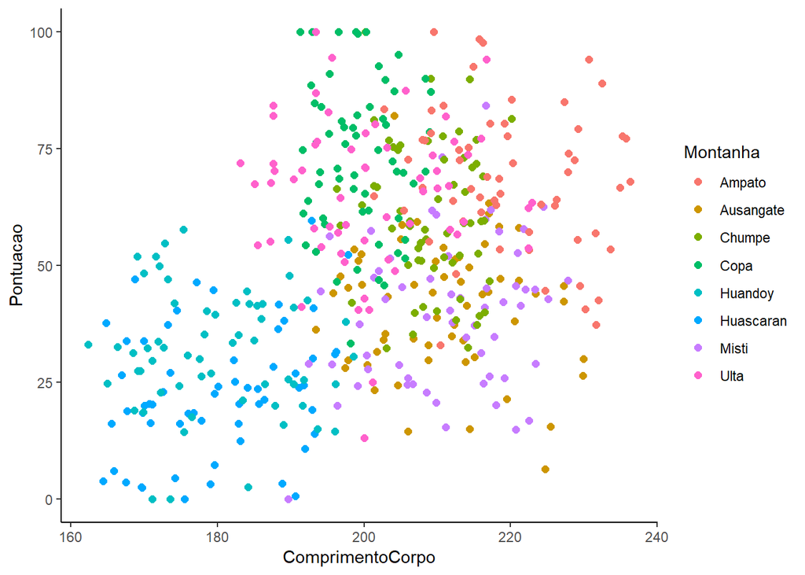

```r
ggplot(condor, aes(x = ComprimentoCorpo, y = Pontuacao, colour = Montanha)) +
  geom_point(size = 2) +
  theme_classic()
```

```r
#+ theme(legend.position = " none"), para não legenda
```

Parece que as nossas montanhas variam tanto no comprimento do corpo do condor quanto nas pontuações dos testes. Isso confirma que nossas observações dentro de cada uma das faixas não são independentes. Nós não podemos ignorar isso.

## Então, o que faremos?

Poderíamos executar muitas análises separadas e ajustar uma regressão para cada uma das montanhas. Vamos dar uma rápida olhada nos dados divididos por montanha. Nós usamos o facet_wrap para fazer isso:

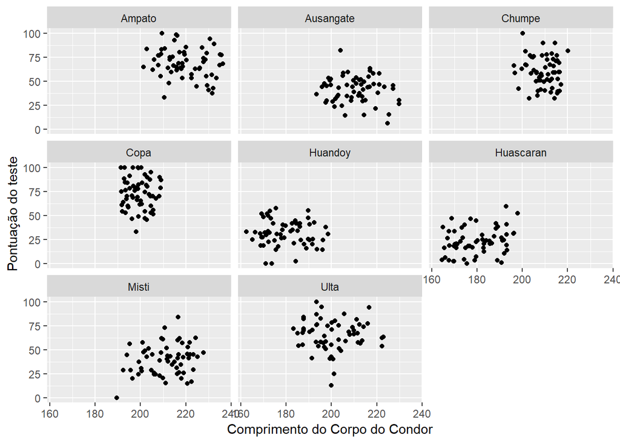

```r
ggplot(aes(ComprimentoCorpo, Pontuacao), data = condor) +
  geom_point() +
  facet_wrap(~ Montanha) +
  xlab("Comprimento do Corpo do Condor") +
  ylab(" Pontuação do teste")
```

Então são oito análises. E também temos locais diferentes, o que, da mesma forma que as montanhas, não são independentes. Assim, podemos executar uma análise para cada local em cada intervalo separadamente.

Para fazer isso, teríamos que estimar um parâmetro de inclinação e intercepto para cada regressão. Veja bem…São dois parâmetros, três locais e oito montanhas, o que significa 48 estimativas de parâmetros (2 x 3 x 8 = 48)! Além disso,

o tamanho da amostra para cada análise seria de apenas 20, isso apresenta problemas, pois não apenas estamos diminuindo o tamanho da amostra , mas também estamos aumentando as chances de um Erro Tipo I (em que você rejeita falsamente a hipótese nula ou seja quando a hipótese nula é verdadeira e você a rejeita) através da realização de comparações múltiplas . Não é ideal!

## Modifique o modelo atual

Queremos usar todos os dados, mas contabilizar os dados provenientes de diferentes montanhas (vamos colocar locais em espera por um segundo para simplificar as coisas).Adicione a montanha como efeito fixo ao nosso modelo2.

```r
modelo2 <- lm(Pontuacao ~ ComprimentoCorpo + Montanha, data = condor)
summary(modelo2)
```

```
##
## Call:
## lm(formula = Pontuacao ~ ComprimentoCorpo + Montanha, data = condor)
##
## Residuals:
##     Min      1Q  Median      3Q     Max
## -52.263  -9.926   0.361   9.994  44.488
##
## Coefficients:
##                    Estimate Std. Error t value Pr(>|t|)
## (Intercept)        65.94519   17.62647   3.741 0.000206 ***
## ComprimentoCorpo    0.01267    0.07974   0.159 0.873787
## MontanhaAusangate -27.36690    2.82480  -9.688  < 2e-16 ***
## MontanhaChumpe     -8.53191    2.85561  -2.988 0.002957 **
## MontanhaCopa        4.76665    3.18070   1.499 0.134644
## MontanhaHuandoy   -36.59507    4.19239  -8.729  < 2e-16 ***
## MontanhaHuascaran -45.11469    4.19012 -10.767  < 2e-16 ***
## MontanhaMisti     -28.90546    2.81624 -10.264  < 2e-16 ***
## MontanhaUlta       -3.13627    3.12364  -1.004 0.315873
## ---
## Signif. codes:  0 '***' 0.001 '**' 0.01 '*' 0.05 '.' 0.1 ' ' 1
##
## Residual standard error: 14.96 on 471 degrees of freedom
## Multiple R-squared:  0.5843, Adjusted R-squared:  0.5773
## F-statistic: 82.76 on 8 and 471 DF,  p-value: < 2.2e-16
```

Agora o comprimento do corpo não é significativo. Mas vamos pensar sobre o que estamos fazendo aqui por um segundo. O modelo acima está estimando a diferença nas pontuações dos testes entre as montanhas, podemos ver todas elas na saída do modelo por summary(). Mas não estamos interessadas nisso, apenas queremos saber se o comprimento do corpo afeta os resultados dos testes e queremos simplesmente controlar a variação proveniente das montanhosas.

Isto é o que nos referimos como “fatores aleatórios” e assim chegamos a modelos de efeitos mistos.

## Modelos de efeitos mistos

Um modelo misto é uma boa escolha aqui: ele nos permitirá usar todos os dados que temos (maior tamanho de amostra) e explicar as correlações entre os dados provenientes dos locais e as montanhas. Também estimaremos menos parâmetros e evitaremos problemas com comparações múltiplas que encontraríamos usando regressões separadas.

Nós vamos trabalhar com a *nlme*, então carregue o pacote (ou use install.packagesse você não tiver nlme no R).

```r
library(nlme)
```

Vamos comentar um pouco sobre os efeitos fixos e aleatórios primeiro, para isso vou dar uma explicação “introdutória”.

Em alguns casos, a mesma variável pode ser considerada um efeito aleatório ou fixo (e às vezes até os dois ao mesmo tempo), Portanto, você deve pensar não apenas em seus dados, mas também nas perguntas que está fazendo e na construção de seus dados.

Em termos gerais, os efeitos fixos são variáveis que esperamos que afetem a variável dependente (resposta). No nosso caso, estamos interessados em tirar conclusões sobre como o comprimento do corpo do condor afeta o resultado do teste do mesmo. Assim, o comprimento do corpo é um efeito fixo e a pontuação do teste é a variável dependente (Resposta).

Efeitos aleatórios (ou fatores aleatórios são geralmente fatores de agrupamento para os quais estamos tentando controlar. Na maioria das vezes, não estamos especificamente interessados em seu impacto na variável de resposta. Além disso, os dados para nosso efeito aleatório são apenas uma amostra de todas as possibilidades. Apenas pense nelas como as variáveis de agrupamento por enquanto.

Neste caso particular, estamos procurando controlar os efeitos da montanha. Nós não experimentamos todas as montanhas do mundo (temos oito), então nossos dados são apenas uma amostra de todas as montanhas existentes. Não estamos realmente interessados no efeito de cada montanha específica na pontuação do teste, mas sabemos que as pontuações dos testes podem ser correlacionadas, portanto, queremos controlar isso. Se especificamente escolhemos oito montanhas a priori e estivéssemos interessados nesses intervalos e quiséssemos fazer previsões sobre eles, então a montanha seria montada como um efeito fixo.

Por exemplo, se quiséssemos controlar os efeitos do sexo do condor na inteligência, ajustaríamos o sexo (um fator de dois níveis: masculino ou feminino) como um efeito fixo, não aleatório .